# Genética quantitativa básica

Diogo Melo

October 16, 2017

# Introdução

Os conceitos da genética quantitativa podem ser melhor entendidos usando um caso simples, de um locus bialélico com efeito no fenótipo. Vamos supor que as frequencias dos alelos A e B são respectivamente p e q, que as frequencias genotípicas estão em equilibrio de Hardy-Weinberg, e que os fenótipos associados a cada genótipo são os seguintes:

|  | genótipos | fenótipos |
| --- | --- | --- |
| 1 | AA | a |
| 2 | AB | d |
| 3 | BB | -a |

Esse valores são medidos a partir da média dos dois homozigotos. Graficamente, a relação entre genótipos e fenótipos é a seguinte:

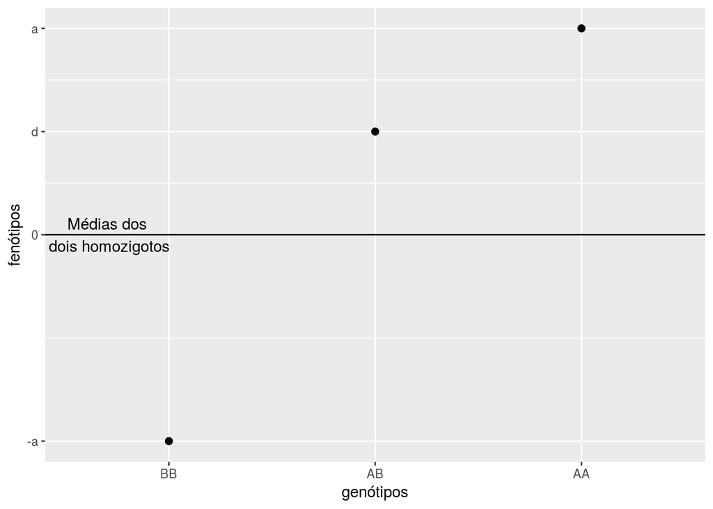

Os valores a e d são chamados efeito aditivos e efeito de dominância. A partir desses valores fenotípicos centralizados na média, podemos calcular a média da população ($M$). Para isso, vamos usar as frequências de Hardy-Weiberg para os genótipos. Ponderando o fenótipo correspondente pela frequência genotípica em equilibrio, a média pode ser escrita como:

$$M = p^2 a + 2pqd + q^2 (-a) = \\
= (p^2 - q^2)a + 2pqd = \\
= (p+q)(p-q)a + 2pqd = \\
= (p-q)a + 2pqd$$

# Efeito médio de substituição

Como estamos interessados em evolução das frequencias alélicas, vamos calcular o efeito médio de substituição ($\alpha$) de um alelo B por um alelo A. Ou seja, como o fenótipo muda, em média, quando ocorre uma mudança de um alelo para o outro.

Existem dois cenários possiveis para a substituição de um alelo B: (1) ou o alelo que acompanha o B é outro B; o o alelo que acompanha o B é um A. A frequencia dos casos é dado apenas pelas frequências na população. Para o caso no qual o alelo B está junto com outro B, se trocarmos um alelo B pelo A, estamos indo de um genótipo BB, com fenótipo $-a$, para um genótipo AB, com fenótipo $d$. Então, a mudança no fenótipo devido à substituição é de $(a + d)$. A outra substituição possével é a de um B acompanhado por um A. Nesse caso, estamos passando de um genótipo AB para AA, e de um fenótipo $d$ para $a$. A diferença então é de $(a-d)$. Ponderando a diferença em cada caso pela frequencia alélica do alelo que não é trocado, temos que o efeito médio de subsituição é dado por:

$$\alpha = (a + d) q + (a - d) p = a + (q - p) d$$

Esse valor pode ser entendido como o coeficiente de uma regressão dos fenótipos no número de alelos A em um dado genótipo. E o quando o fenótipo muda, em média, a medida que acrescentamos um alelo A. Graficamente, para uma população com frequencias $p = 0.4$ e $q = 0.6$ e efeitos $a = 1$ e $d = 0.5$:

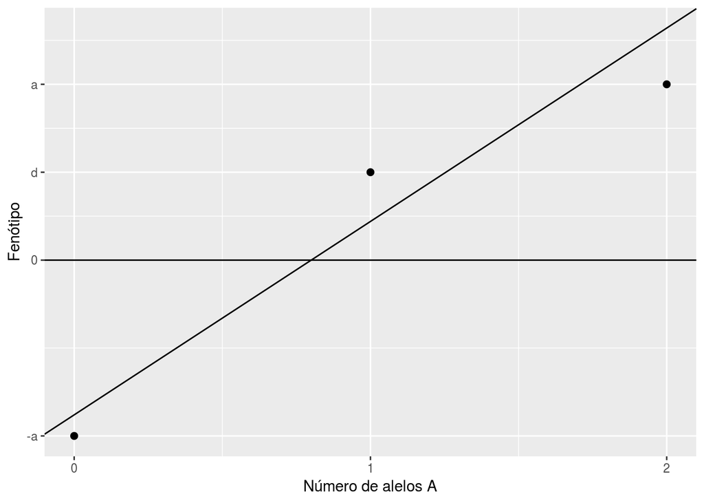

# Efeito médio de um alelo

Vamos agora calcular a diferença na média dos individuos que tem o alelo A para a média da população. Como a transmissão entre gerações é de alelos e não genótipos, essa é a quantidade mais fundamental para a semelhança entre pais e filhos e para a evolução. Para calcular o efeito médio do alelo A nessa população, vamos pensar em todas as possibilidades de de encontrarmos pelo menos um alelo A. Como essa população é bialélica, o alelo A pode estar acompanhado de outro A ou de um B, e esses dois casos vão acontecer de acordo com as frequências alélicas. Para o caso no qual o A é acompanhado de outro A, a frequencia é p e o fenótipo é $a$. Para o caso no qual o A é acompanhado de um B, a frequencia é q e o fenótipo é $d$. Então, a média dos individuos que contem pelo menos um alelo A é de:

$$pa + qd$$

Mas essa é uma média abosluta, e o efeito médio do alelo A ($\alpha_A$) é a diferença entre a média da população e a média dos individuos que contém o alelo A. Vamos calcular essa diferença, lembrando que M é a média da população que calculamos anteriormente:

$$\alpha_A = pa + qd - M = (pa + qd) - [(p-q)a + 2pqd] = \\
= pa + qd - pa + qa - 2pqd = \\
= qa + (q - 2pq) d = \\
= [qa + (q - pq - pq)d] = \\
= q[a + (1 - p - p)d] = \\
= q[a + (q - p)d] = q \alpha$$

Note que o valor entre conchetes é exatamente o efeito médio de substituição ($\alpha$). Podemos fazer a mesma conta para o alelo B, e vamos econtrar que o efeito médio do alelo B ($\alpha_B$) é:

$$\alpha_B = -p[a + (q - p)d] = -p \alpha$$

# Valor de acasalamento

O valor de acasalamento é a soma dos efeitos médios de todos os alelos de um indivíduo. Então, para os nossos 3 genótipos, os valores de acasalamento são:

| Genótipos | Valor de acasalamento |
| --- | --- |
| AA | $2\alpha_A = 2q\alpha$ |
| AB | $\alpha_A + \alpha_B = (q - p)\alpha$ |
| BB | $2\alpha_B = -2p\alpha$ |